# Principal Component Analysis on Alaskan FIA Dataset

2025-03-17, updated 2025-05-27

**Tara Disser**

**Prerequisites**

```r
library(ggplot2) # general plotting
library(psych) # scree test
library(ggfortify) # biplot
library(corrplot) # correlation matrix
```

**The Dataset**

```r
fia <- read.csv("Data/Final_FIA_plot_climateData.csv")
head(fia)
```

```
##       FIA_Plot mean_annual_temp_degC mean_annual_ppt_cm elevation_meters
## 1 2.494475e+14                 -1.46             347.72         390.7345
## 2 2.494475e+14                 -2.81             360.75         182.8711
## 3 2.494475e+14                 -2.97             447.63         728.7412
## 4 2.494475e+14                 -2.46             366.25         417.8604
## 5 2.494475e+14                 -1.99             354.70         262.7248
## 6 2.494475e+14                 -2.01             378.88         294.7272
##   Potential_Evapotranspiration_mm_per_month GrowingSeasonLength_months Location
## 1                                  60.28339                   3.367161   Alaska
## 2                                  63.61910                   3.376234   Alaska
## 3                                  63.23100                   3.265435   Alaska
## 4                                  62.57386                   3.363687   Alaska
## 5                                  59.90066                   3.383235   Alaska
## 6                                  61.95027                   3.388661   Alaska
```

This Forest Inventory and Analysis dataset contains some Alaskan forestry climate data that I will be analyzing. FIA_Plot and Location give us some location data, and for each location, we have data on the mean annual temperature and precipitation, as well as the elevation, potential evapotranspiration per month, and the length of the growing season.

Let’s begin by visualizing the relationships between each of these variables:

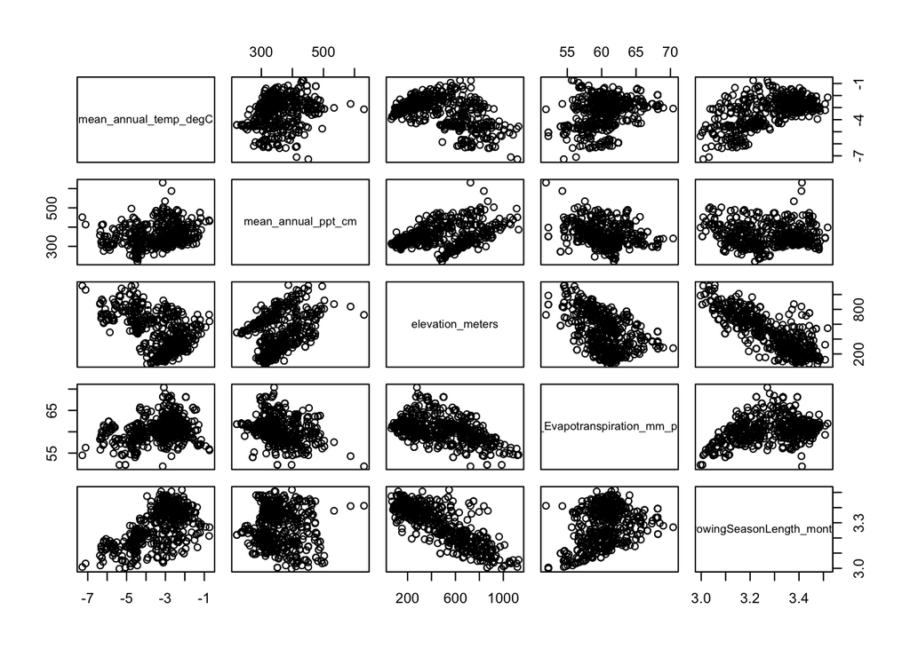

```r
fia_matrix <- fia[, 2:6]
pairs(fia_matrix)
```

It’s a bit difficult to see association in these plots… Let’s instead create a correlation matrix:

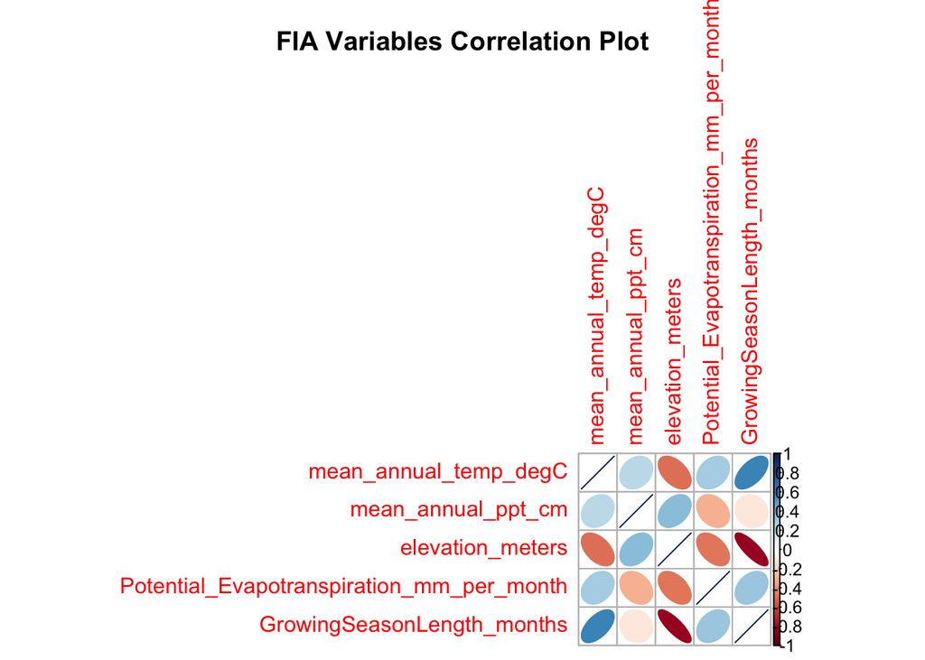

```r
fia_correlations <- cor(fia_matrix)
corrplot::corrplot(fia_correlations, method = "ellipse")
mtext("FIA Variables Correlation Plot", side = 3, line = 2, font = 2, cex = 1.2)
```

Looks like we have a few notable correlations here:  
-Strong negative correlation between elevation and growing season length  
-Medium strength negative correlation between elevation and potential evapotranspiration per month  
-Medium strength negative correlation between elevation and mean annual temperature  
-Medium strength positive correlation between growing season length and mean annual temperature  
We’ll plan to revisit these relationships once we run our principal component analysis. Let’s start that now:

```r
fia_pca <- prcomp(fia_matrix, scale=TRUE) # perform PCA on standardized variables
summary(fia_pca)
```

```
## Importance of components:
##                           PC1    PC2    PC3     PC4     PC5
## Standard deviation     1.6087 1.1340 0.8209 0.56602 0.36304
## Proportion of Variance 0.5176 0.2572 0.1348 0.06408 0.02636
## Cumulative Proportion  0.5176 0.7748 0.9096 0.97364 1.00000
```

The proportion of variance (derived from eigenvalues associated with each PC) tells us just how much information/variance in the data set can be explained by each component. It looks like PC1 explains a little over half of the variance, PC2 explains an additional 26%, and PC3, 13%.

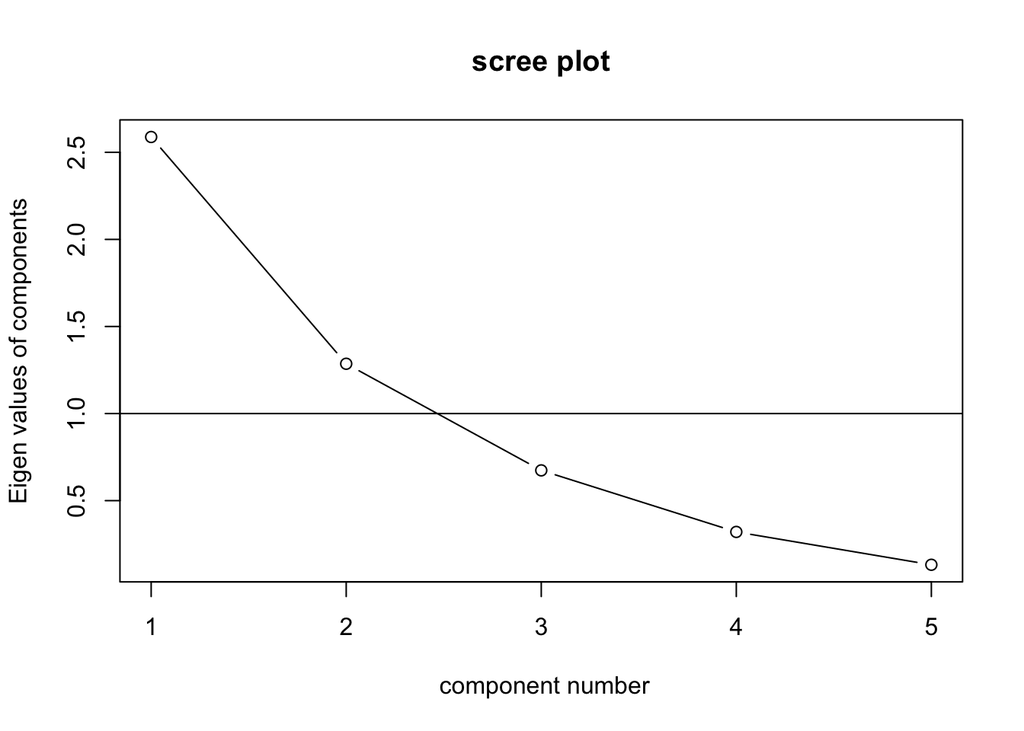

```r
psych::VSS.scree(fia_matrix)
```

This Scree plot gives us a visual representation of the variance explained by each of the components and can help us determine how many components we should use for further analysis. Based on this combined with the summary produced previously, it seems like the first 2 components can explain the majority of our data.

```r
loadings <- as.data.frame(fia_pca$rotation)
loadings
```

```
##                                                  PC1        PC2        PC3
## mean_annual_temp_degC                     -0.4253740  0.5195007  0.1618248
## mean_annual_ppt_cm                         0.1855501  0.7845538  0.2279959
## elevation_meters                           0.5739609  0.1050821  0.2796130
## Potential_Evapotranspiration_mm_per_month -0.3977240 -0.2724966  0.8414399
## GrowingSeasonLength_months                -0.5449887  0.1711657 -0.3682744
##                                                  PC4         PC5
## mean_annual_temp_degC                     -0.7211698  0.05387881
## mean_annual_ppt_cm                         0.4886910 -0.24340391
## elevation_meters                          -0.1441688  0.74870462
## Potential_Evapotranspiration_mm_per_month  0.2326156  0.07368854
## GrowingSeasonLength_months                 0.4076771  0.60980570
```

These loadings correspond to scaled eigenvectors whose directions represent how “aligned” each variable is with each principal component.

Looking at our first principal component, elevation and length of growing season have the greatest magnitudes and thus are the most “aligned” with PC1. Looking at our second principal component, we see the greatest magnitudes in mean annual precipitation and mean annual temperature. Let’s see if we can notice this in some biplots, which give us a visual representation of this “alignment.”

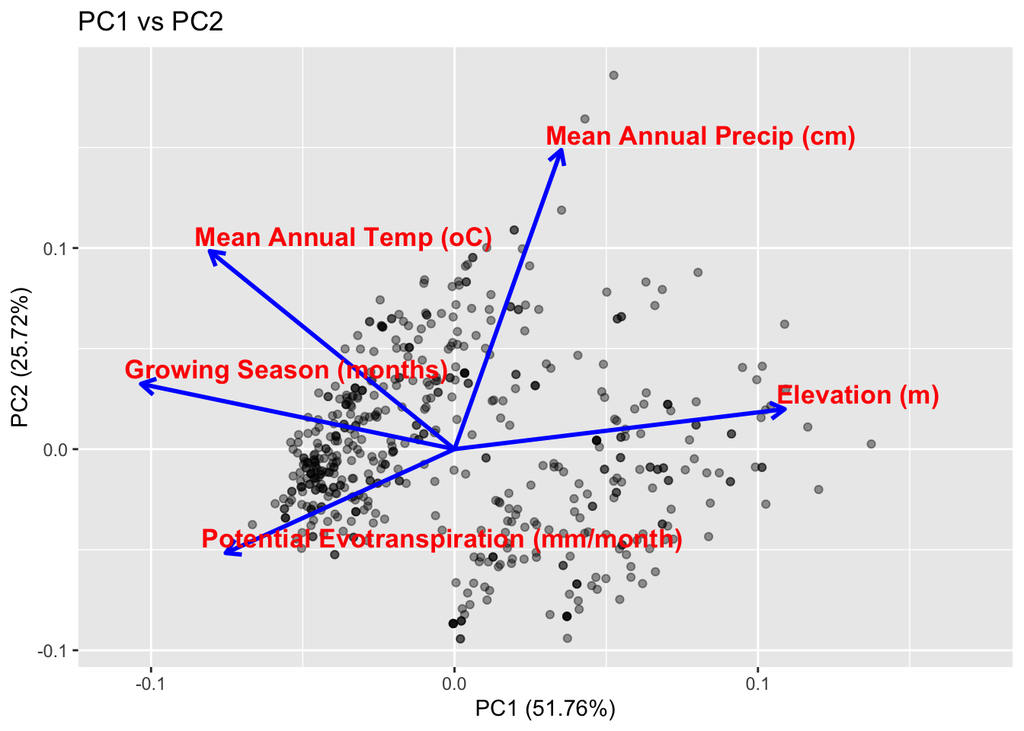

```r
pc_vars_arr <- c("Mean Annual Temp (oC)",
             "Mean Annual Precip (cm)",
             "Elevation (m)",
             "Potential Evotranspiration (mm/month)",
             "Growing Season (months)")
      # Nicely formatted variable names

ggplot2::autoplot(fia_pca, data = fia_matrix,
         main = "PC1 vs PC2",
         alpha = .4, # making the plot look nice from here and down
         loadings = TRUE, loadings.color = 'blue',
         loadings.label = TRUE, loadings.label.label = pc_vars_arr,
         loadings.label.hjust = .05, loadings.label.angle = 0, loadings.label.vjust = -.3,
         loadings.linewidth = 1, loadings.label.fontface = 'bold',
         loadings.label.size = 4.5,
         xlim = c(-.11, .17))
```

The relatively similar lengths of all variable-representing arrows on PC1 and PC2 (which are the principal components that we care most about) suggest that each variable is contributing a good amount to the variance in the data - there are no variables that we should necessarily “drop” at this point.

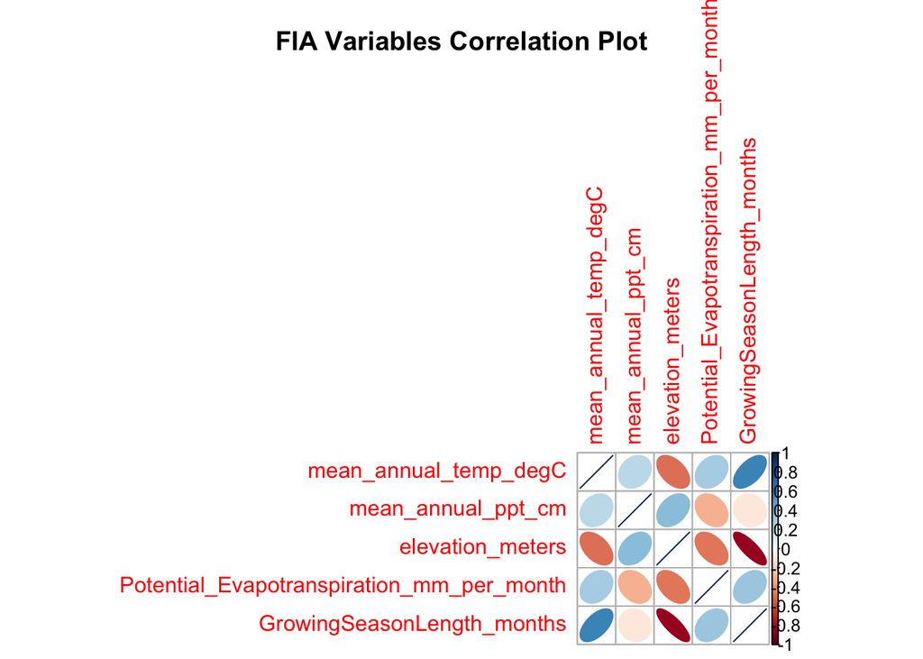

```r
corrplot(fia_correlations, method = "ellipse")
mtext("FIA Variables Correlation Plot", side = 3, line = 2, font = 2, cex = 1.2)
```

Let’s remember some of the correlations we saw previously and connect them to some of our PCA conclusions:  
-Strong negative correlation between elevation and growing season length  
-Medium strength negative correlation between elevation and potential evapotranspiration per month  
-Medium strength negative correlation between elevation and mean annual temperature

All of these variables have similar (and larger) magnitudes on PC1, which makes sense as we would expect highly correlated variables to contribute similar information to our data set.

A rough conclusion of this analysis might suggest that all variables in the dataset contribute to the variance to a reasonable extent, and we may not necessarily want to “drop” any variables in continuing to analyze the data. If we really wanted to find something, we might look to variables’ “association” to PC3, which explains an additional ~13.5% of our variance - nothing major, but still noticeable.

**END**